# Bike Sharing

Aga, Karla, Nisse, Ole

2024-01-17

# Abstract

[figure not shown]

“*Bikesharing contributes to the advent of more sustainable transportation in cities around the globe.*” (Béland 2014). Bikesharing programs are designed to provide short-term bicycle rental in stations dispersed throughout the cities and located near public transportation hubs (Béland 2014). They have numerous environmental and health benefits, such as reducing congestion, complementing other forms of public transportation and encouraging exercise (Béland 2014). Additionally, accessible bike rental has a lower barrier of entry than purchasing your own bike and is more convenient for out-of-town commuters.

In principle bicycles pose a good substitute for car use in urban areas, however, they have certain limitations. Among them is the exposure of cyclists to weather while commuting compared to other means of transportation. It would be intuitive for the number of bike rentals to be dependent on current weather conditions. If that is the case, the extent of that relationship would be important information for the bikesharing companies. Potentially, the information could be a factor in variety if business decisions, including level of pricing or supply for bikes in different seasons.

Considering these possible applications, this report will attempt to answer: **To what extent can weather data predict the number of bike rentals in different parts of the day?** Weather data is understood in terms of temperature, wind speed, humidity and occurrence of weather phenomena (including storms, snow and rain).

# Dataset

The dataset was retrieved from the open-source machine learning repository [UC Irvine](https://archive.ics.uci.edu/dataset/275/bike+sharing+dataset) and Hadi Fanaee-T from the Laboratory of Artificial Intelligence and Decision Support (LIAAD), University of Porto is credited as its author. The bike rentals data originates from the Capital Bikeshare company based in Washington DC, United States. The dataset contains the hourly and daily counts of bike rentals and weather data in the years 2011 and 2012 in the American capital. We opted to use the hourly data due for modeling, due to the larger sample size (the dataset consists of 17379 data points) and less aggregated data. We found the smaller degree of aggregation important, as weather can change drastically throughout a 24 hour period. In case of further interest or replication of our research analysis, you can trace the link to this dataset at the end of this paper in our References

# Loading data

The repository provided us with three files, namely:

- `hour.csv`, hourly data of bike rentals.
- `day.csv`, daily data of bike rentals.
- `README.txt`, providing additional metadata about the file and their data.

```r
library(tidyverse)
library(fastDummies)
library(kableExtra)
library(gridExtra, exclude="combine")
library(lubridate)
library(car)
library(ICC)
library(caret)
```

```r
# Source hourly data for model
source_data <- read.csv("../data/hour.csv", header = TRUE, sep = ",") %>%
  as_tibble()

# Extra daily data for EDA
day_df <- read.csv("../data/hour.csv", header = TRUE, sep = ",") %>%
  as_tibble()

# Clone source
data <- source_data

head(data)
```

| instant | dteday | season | yr | mnth | hr | holiday | weekday | workingday | weathersit | temp | atemp | hum | windspeed | casual | registered | cnt |
| --- | --- | --- | --- | --- | --- | --- | --- | --- | --- | --- | --- | --- | --- | --- | --- | --- |
| 1 | 2011-01-01 | 1 | 0 | 1 | 0 | 0 | 6 | 0 | 1 | 0.24 | 0.2879 | 0.81 | 0.0000 | 3 | 13 | 16 |
| 2 | 2011-01-01 | 1 | 0 | 1 | 1 | 0 | 6 | 0 | 1 | 0.22 | 0.2727 | 0.80 | 0.0000 | 8 | 32 | 40 |
| 3 | 2011-01-01 | 1 | 0 | 1 | 2 | 0 | 6 | 0 | 1 | 0.22 | 0.2727 | 0.80 | 0.0000 | 5 | 27 | 32 |
| 4 | 2011-01-01 | 1 | 0 | 1 | 3 | 0 | 6 | 0 | 1 | 0.24 | 0.2879 | 0.75 | 0.0000 | 3 | 10 | 13 |
| 5 | 2011-01-01 | 1 | 0 | 1 | 4 | 0 | 6 | 0 | 1 | 0.24 | 0.2879 | 0.75 | 0.0000 | 0 | 1 | 1 |
| 6 | 2011-01-01 | 1 | 0 | 1 | 5 | 0 | 6 | 0 | 2 | 0.24 | 0.2576 | 0.75 | 0.0896 | 0 | 1 | 1 |

We then create a sub-selection of variables that are of interest for our model; these are the control, predictor and outcome variables, as well as, variables necessary for EDA and preprocessing.

```r
data <- select(data,
               dteday,
               hr,
               workingday,
               weathersit,
               temp,
               atemp,
               hum,
               windspeed,
               casual,
               registered,
               cnt)
```

## Variables description

| Role | Variable | Name | Type | Characteristics |
| --- | --- | --- | --- | --- |
| Outcome component | Number of non-subscribed rentals | casual | Continuous |  |
| Outcome component | Number of subcribed rentals | registered | Continuous |  |
| Outcome component | Number of total rentals | cnt | Continuous |  |
| Predictor | Working day indicator | workingday | Categorical | Binary, 1 for working days |
| Predictor | Temperature | temp | Continuous | Normalized 0-1 originally in Celsius |
| Predictor | Feeling temperature | atemp | Continuous | Normalized 0-1 originally in Celsius |
| Predictor | Humidity | hum | Continuous | Normalized 0-1 |
| Predictor | Wind speed | windspeed | Continuous | Normalized 0-1 |
| Predictor | Weather phenomena | weathersit | Categorical | 4 categories, with 4 being the worst weather conditions |
| Data processing | Hour | hr | Categorical | Categories 0 to 23 |
| Data processing | Date | dteday | Character | YYYY-MM-DD format |

The table above does not contain a raw outcome variable as of yet. Rather, three variables - namely `casual`, `registered` and `cnt` - are components that will be utilised when creating our outcome variable later on.

The categories of `weathersit` represent the following weather phenomena and their combinations:

1. Clear, Few clouds, Partly cloudy, Partly cloudy
2. Mist and Cloudy, Mist and Broken clouds, Mist and Few clouds, Mist
3. Light Snow, Light Rain and Thunderstorm and Scattered clouds, Light Rain and Scattered clouds
4. Heavy Rain and Ice Pallets and Thunderstorm and Mist, Snow and Fog

# Preprocessing & EDA

## Type checking

Some of our categorical variables (i.e. `workingday`, `weathersit`, `hr`) are interpreted as integers rather than factors. We transform these data to factors for ease of processing and modeling.

```r
data <- data %>%
  mutate(
    workingday = as.factor(workingday),
    weathersit = as.factor(weathersit),
    hr = as.factor(hr)
  )
```

## Creating Additional Variables

### Create outcome variable

By combining the component outcome variables mentioned in Variable description, we create `registered_prop`, which is the proportion subscribed rentals of the total rental count. Consequently, we use the mean of this variable to create a binary outcome variable called `more_registered`.

```r
# Create binary variable, returning true if proportion is higher than respective mean.
create_ouctome <- function(prop, mean) {
    ifelse(prop > mean, 1, 0) %>%
    as.factor()
}

# Bind binary variable to data.
data <- data %>%
  mutate(
    registered_prop = registered / cnt,
    more_registered = create_ouctome(registered_prop, mean(registered_prop))
  )

# Inspect data.
head(data)
```

| dteday | hr | workingday | weathersit | temp | atemp | hum | windspeed | casual | registered | cnt | registered_prop | more_registered |
| --- | --- | --- | --- | --- | --- | --- | --- | --- | --- | --- | --- | --- |
| 2011-01-01 | 0 | 0 | 1 | 0.24 | 0.2879 | 0.81 | 0.0000 | 3 | 13 | 16 | 0.8125000 | 0 |
| 2011-01-01 | 1 | 0 | 1 | 0.22 | 0.2727 | 0.80 | 0.0000 | 8 | 32 | 40 | 0.8000000 | 0 |
| 2011-01-01 | 2 | 0 | 1 | 0.22 | 0.2727 | 0.80 | 0.0000 | 5 | 27 | 32 | 0.8437500 | 1 |
| 2011-01-01 | 3 | 0 | 1 | 0.24 | 0.2879 | 0.75 | 0.0000 | 3 | 10 | 13 | 0.7692308 | 0 |
| 2011-01-01 | 4 | 0 | 1 | 0.24 | 0.2879 | 0.75 | 0.0000 | 0 | 1 | 1 | 1.0000000 | 1 |
| 2011-01-01 | 5 | 0 | 2 | 0.24 | 0.2576 | 0.75 | 0.0896 | 0 | 1 | 1 | 1.0000000 | 1 |

```r
prop_mean = mean(data$registered_prop)
```

### Expand `dteday` data

```r
# Converts datetime string to numeric with origin offset.
date_to_num <- function(date, offset) {
   as.integer(as.Date(date, "%Y-%m-%d")) - offset
}

# Fetch origin.
dt_offset <- source_data$dteday[1] %>%
  date_to_num(0) - 1


data <- data %>%
  mutate(
    dt_num = date_to_num(dteday, dt_offset)
  )

# Global variable for amount of unique days.
n_days <- n_distinct(data$dteday)
```

## Descriptive Statistics

We obtained the descriptive statistics of our variables.

```
##     dteday                hr        workingday weathersit      temp
##  Length:17379       16     :  730   0: 5514    1:11413    Min.   :0.020
##  Class :character   17     :  730   1:11865    2: 4544    1st Qu.:0.340
##  Mode  :character   13     :  729              3: 1419    Median :0.500
##                     14     :  729              4:    3    Mean   :0.497
##                     15     :  729                         3rd Qu.:0.660
##                     12     :  728                         Max.   :1.000
##                     (Other):13004
##      atemp             hum           windspeed          casual
##  Min.   :0.0000   Min.   :0.0000   Min.   :0.0000   Min.   :  0.00
##  1st Qu.:0.3333   1st Qu.:0.4800   1st Qu.:0.1045   1st Qu.:  4.00
##  Median :0.4848   Median :0.6300   Median :0.1940   Median : 17.00
##  Mean   :0.4758   Mean   :0.6272   Mean   :0.1901   Mean   : 35.68
##  3rd Qu.:0.6212   3rd Qu.:0.7800   3rd Qu.:0.2537   3rd Qu.: 48.00
##  Max.   :1.0000   Max.   :1.0000   Max.   :0.8507   Max.   :367.00
##
##    registered         cnt        registered_prop  more_registered
##  Min.   :  0.0   Min.   :  1.0   Min.   :0.0000   0:7497
##  1st Qu.: 34.0   1st Qu.: 40.0   1st Qu.:0.7463   1:9882
##  Median :115.0   Median :142.0   Median :0.8531
##  Mean   :153.8   Mean   :189.5   Mean   :0.8279
##  3rd Qu.:220.0   3rd Qu.:281.0   3rd Qu.:0.9365
##  Max.   :886.0   Max.   :977.0   Max.   :1.0000
##
##      dt_num
##  Min.   :  1.0
##  1st Qu.:185.0
##  Median :367.0
##  Mean   :367.2
##  3rd Qu.:549.0
##  Max.   :731.0
##
```

## Distributions

Since the summaries are not giving a precise enough picture, we histograms of the variables.

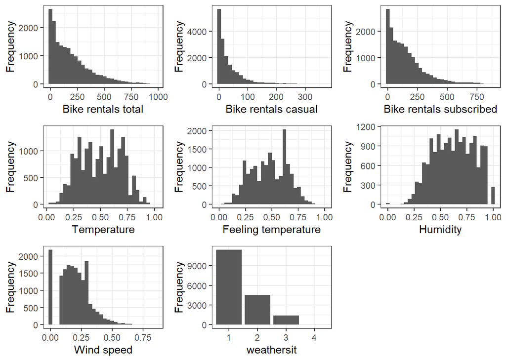

The weather phenomena histograms reveals that the 4th category, the harshest weather phenomena, is barely present. If we use it in our model, the category would be a categorical outlier and needs to be addressed.

The distribution of temperature and feeling temperature is quite normal. However, both humidity and wind speed have a number of `0` values that are disjointed from the rest of the data. They may constitute possible outliers and we will look at them closer in the next section.

## Outliers

Since there was an indication of outliers, we decided to detect them using quantiles. We made the following box plots:

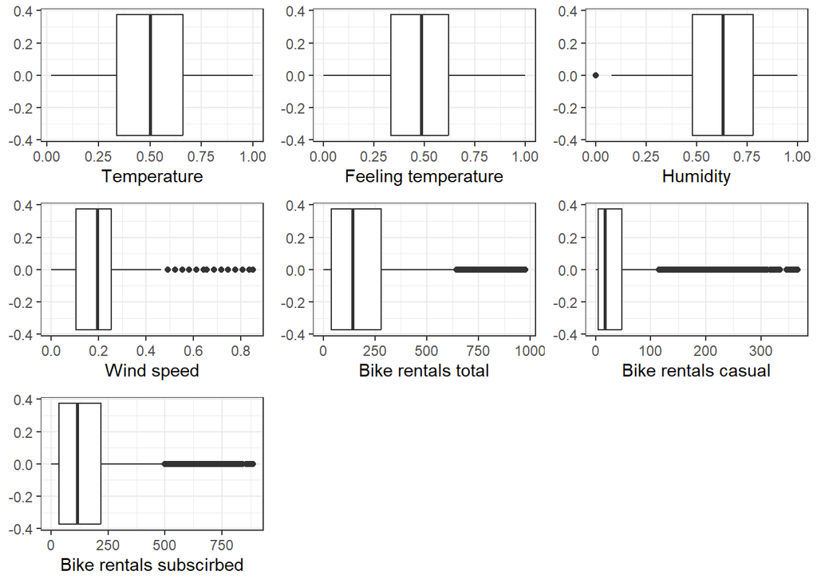

The box plots further support our observations from earlier. Temperature and feeling temperature are distributed very normally and display no outliers on the box plots. Humidity has a a few `0` values that are flagged as outliers. In the wind speed, the large number of `0` values skews the distribution towards the smaller values, leaving a lot of the high wind speeds as outliers. The box plot of number of bike rentals reveals a large number of outliers in our outcome component variable. A similar pattern can be observed for the casual and registered bike rentals.

We investigate the “problematic” variables: humidity, wind speed and number of rentals, further below:

### Rental count outliers

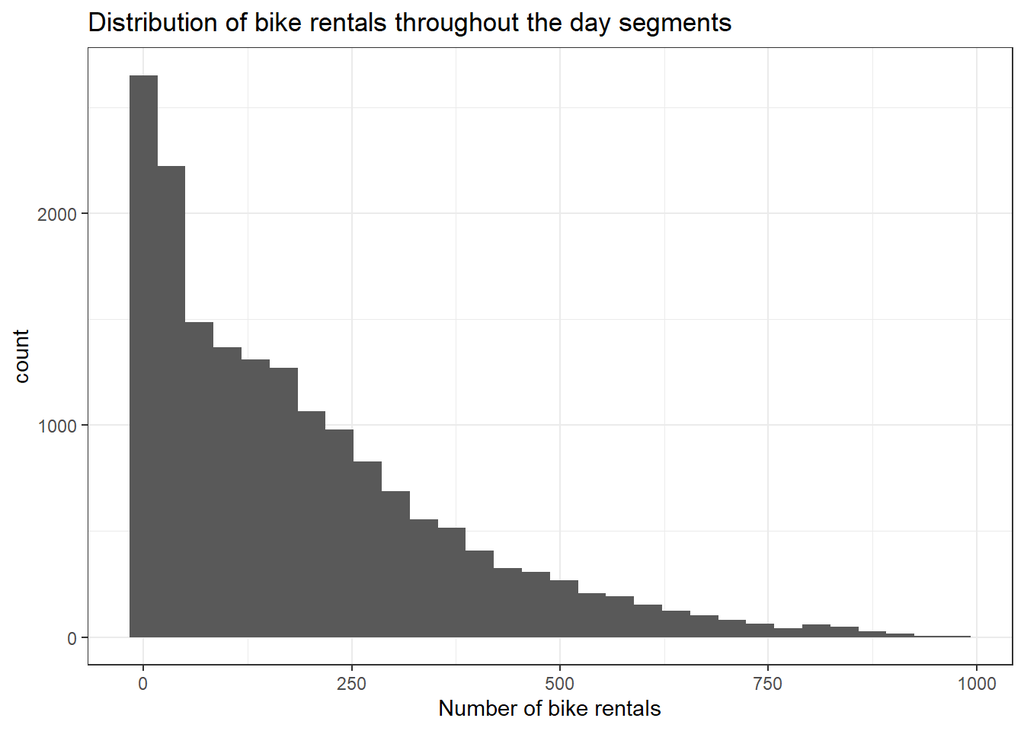

[figure not shown]

### Windspeed outliers

The distribution of wind speed is right-skewed, hence large values are seen as outliers. We do note the presence of gap between `0` values and the first non-zero values, specifically:

```r
data %>%
  group_by(windspeed) %>%
  summarise(n = n()) %>%
  arrange(windspeed) %>%
  head()
```

| windspeed | n |
| --- | --- |
| 0.0000 | 2180 |
| 0.0896 | 1425 |
| 0.1045 | 1617 |
| 0.1343 | 1738 |
| 0.1642 | 1695 |
| 0.1940 | 1657 |

While the `0.00` values fall within the distribution, it is only odd that there’s a small increment between the `0.00` occurrences and the values thereafter (e.g. `0.0869`). This might be due to sensor threshold for measuring wind speed or these might also be possible missing values which were replaced with `0.00`. Since we cannot know for certain and the number of occurrences for `0.00` is in line with neigbouring values, we choose to keep them.

### Humidity outliers

A similar gap between `0.00` values and the next non-zero value occurs in the humidity variable:

```r
data %>%
  group_by(hum) %>%
  summarise(n = n()) %>%
  arrange(hum) %>%
  head()
```

| hum | n |
| --- | --- |
| 0.00 | 22 |
| 0.08 | 1 |
| 0.10 | 1 |
| 0.12 | 1 |
| 0.13 | 1 |
| 0.14 | 2 |

In fact, there are 22 hours in which the value is registered. Humidity of `0.00` is not possible in nature, which suggests that the values might be a mistake or a missing value. However, the values have been normalized and we do not know the specific method used. Thus, there is a significant possibility that the value `0.00` does not represent a true `0.00` humidity and is just the minimal value in the data. Since the number of these outliers is small and they could be real data, we chose to keep them.

### Weathersit outliers

```r
# Inspect occurrence count for weathersit categories.
data %>%
  count(weathersit)
```

| weathersit | n |
| --- | --- |
| 1 | 11413 |
| 2 | 4544 |
| 3 | 1419 |
| 4 | 3 |

```r
# Filter weathersit 4 outliers.
data <- data %>%
  filter(weathersit != 4)
```

## Missing data

The dataset’s source claimed there is no missing data. We verified that, by checking if any standard NA values are present.

```r
anyNA(data)
```

```
## [1] FALSE
```

### Missing records for hour

As mentioned before the only type of missing data is the fact that our dataset is not complete in terms of containing all the hours of the two years. Some `hr` values seem to have a lower amount of occurrences than others, as can be seen below:

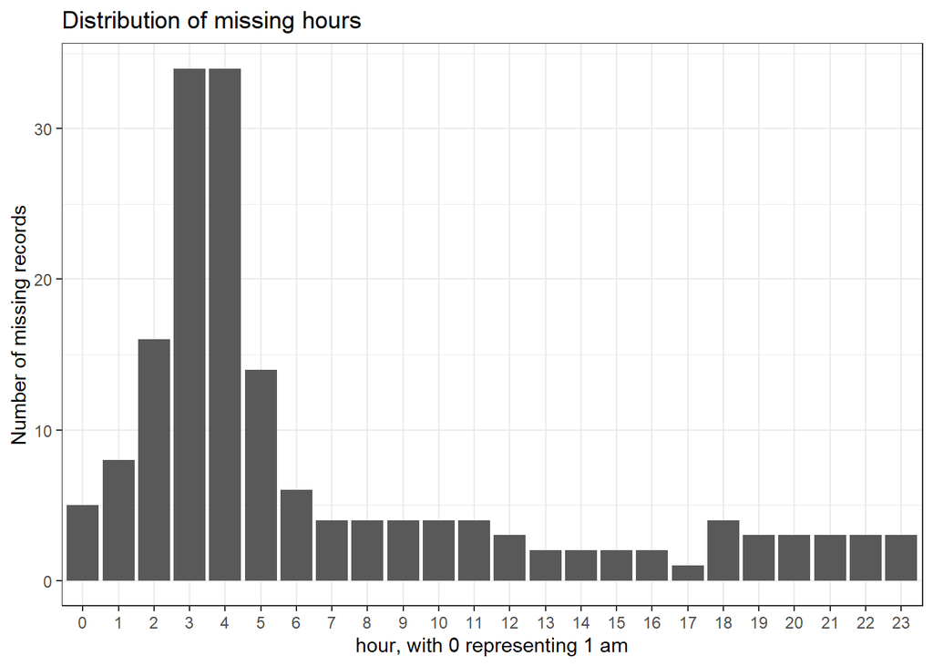

Thus, most of the missing hours are between 3am and 6am. The lack of records during the night could be potentically caused by maintenance conducted by the rental company at those hours, time changes or shortage of night workers. To investigate further we decided to see during which days are the missing hours present:

*Table showing days with the highest number of missing records*

| dteday | n_missing_records |
| --- | --- |
| 2012-10-29 | 23 |
| 2011-01-27 | 16 |
| 2012-10-30 | 13 |
| 2011-01-18 | 12 |
| 2011-01-26 | 9 |
| 2011-08-28 | 7 |
| 2011-02-22 | 6 |
| 2011-08-27 | 6 |
| 2011-01-03 | 2 |
| 2011-01-11 | 2 |

## Relations

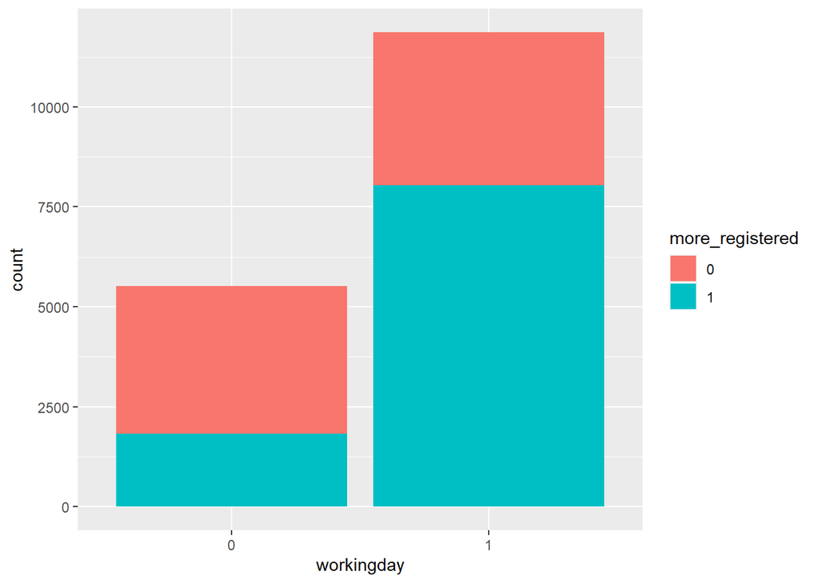

```r
ggplot(data, aes(workingday)) +
  geom_bar(aes(fill = more_registered))
```

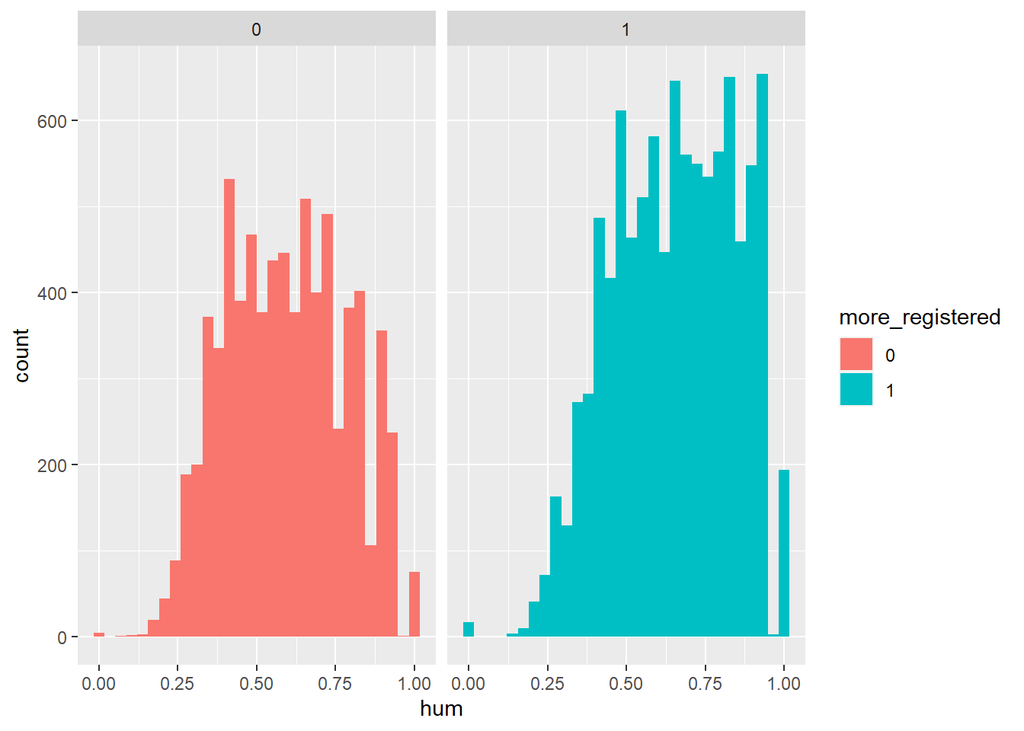

```r
ggplot(data, aes(hum)) +
  geom_histogram(aes(fill = more_registered)) +
  facet_wrap(~ more_registered)
```

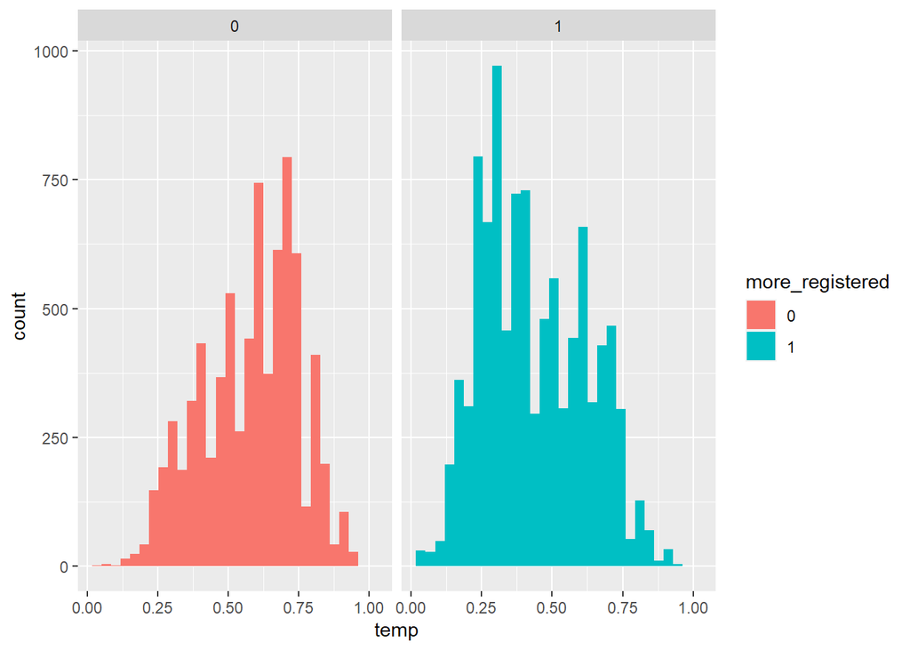

```r
ggplot(data, aes(temp)) +
  geom_histogram(aes(fill = more_registered)) +
  facet_wrap(~ more_registered)
```

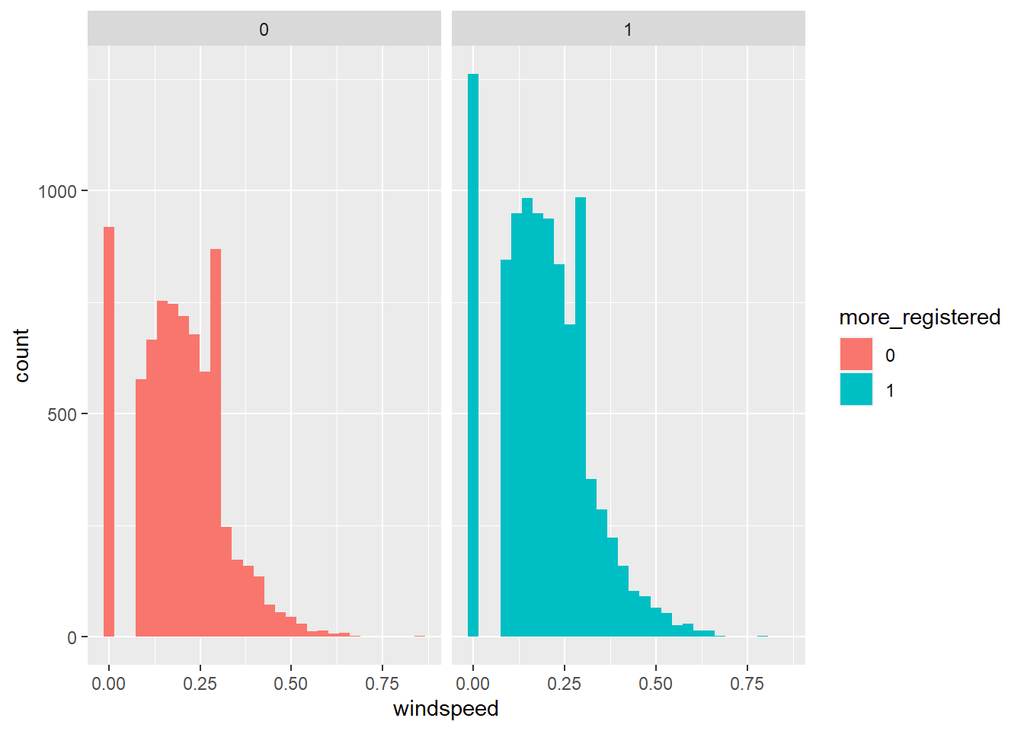

```r
ggplot(data, aes(windspeed)) +
  geom_histogram(aes(fill = more_registered)) +
  facet_wrap(~ more_registered)
```

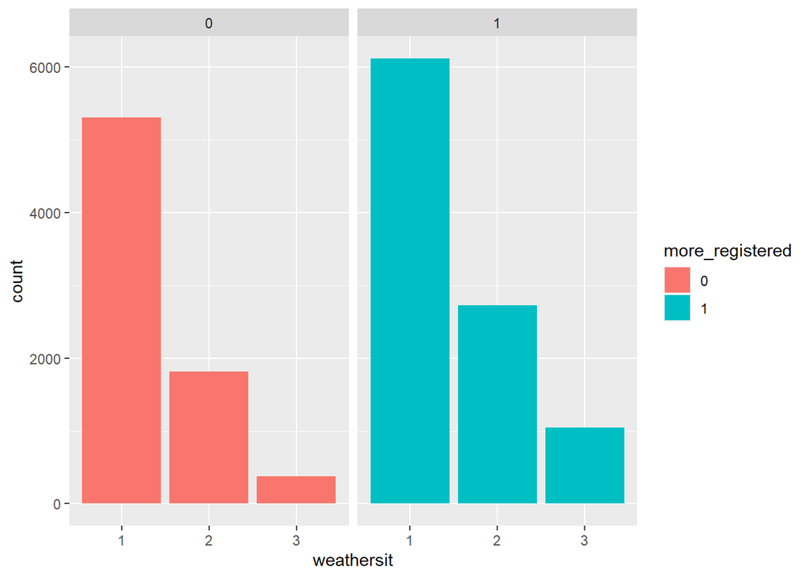

```r
ggplot(data, aes(weathersit)) +
  geom_bar(aes(fill = more_registered)) +
  facet_wrap(~ more_registered)
```

# Model selection - Phase 1

Our approach to modeling was to build up nested models using the step-up strategy (Grace-Martin 2023) - starting with an empty intercept-model - and adding potential predictors in a step-wise manner. The order in which these predictors were added was based on the previous analysis done in Relations, starting with variables that seemed to affect the outcome variable the most. From said analysis, we concluded that `workingday` had the strongest effect on our outcome variable - hence this was the first predictor that was to be added. Building on top of that, we added the remaining variables one by one in order of decreasing effect.  
Logistic regression models do not have an $R^2$ statistic. Instead, we used the *residual deviance* $D$ in order to compare model fit improvement between models. The significance of this improvement was validated using *likelihood ratio tests* between two nested (adjacent) models. To also take into account the increase of model complexity when adding in predictors, we utilised the *AIC* and *BIC* measures in our comparison process.  
A total of 6 non-moderated models were created, all of which were an improvement compared to their parent version. Consequently, model 5 (zero-based) was identified as our best model based on the *AIC*, *BIC* and $D$ statistics. This model includes all the weather predictors, as well as the `workingday` indicator.  
Lastly, we checked whether `workinday` moderated the relation between our weather predictors and our outcome variable by creating our last model - model 6. We tested if adding the moderation was a significant improvement by once again comparing the *AIC* and *BIC* values between our moderator model and the “best model”, whilst also performing a *likelihood ratio test* between the two.

The entirety of this process is reflected in the code below.

We start by creating the models:

```r
# Create logistic models.
model0 <- glm(more_registered ~ 1, family = binomial, data)
model1 <- glm(more_registered ~ workingday, family = binomial, data)
model2 <- glm(more_registered ~ workingday + temp, family = binomial, data)
model3 <- glm(more_registered ~ workingday + temp + hum, family = binomial, data)
model4 <- glm(more_registered ~ workingday + temp + hum + windspeed, family = binomial, data)
model5 <- glm(more_registered ~ workingday + temp + hum + windspeed + weathersit, family = binomial, data)

# Add working day moderator on weather predictors.
model6 <- glm(more_registered ~ workingday*(windspeed + temp + hum) + weathersit, family = binomial, data)
```

Having created the models, we can obtain the required comparison statistics and display them in a table:

```r
# Obtain residual deviance statistic from model.
RD <- function(model) {
  summary(model)$deviance
}

# Create AIC, BIC and D table for all the models.
comp_df <- data.frame(
  model = c('model0', 'model1', 'model2', 'model3', 'model4', 'model5', 'model6'),
  predictors = c('', 'workingday', 'workingday + temp', 'workingday + temp + hum', 'workingday + temp + hum + windspeed', 'workingday + temp + hum + windspeed + weathersit', 'workingday + temp + hum + windspeed + weathersit'),
  moderator = c('', '', '', '', '', '', 'workingday'),
  AIC = c(AIC(model0), AIC(model1), AIC(model2), AIC(model3), AIC(model4), AIC(model5), AIC(model6)),
  BIC = c(BIC(model0), BIC(model1), BIC(model2), BIC(model3), BIC(model4), BIC(model5), BIC(model6)),
  D = c(RD(model0), RD(model1), RD(model2), RD(model3), RD(model4), RD(model5), RD(model6))
)

comp_df %>%
  kable()%>%
  kable_styling()
```

| model | predictors | moderator | AIC | BIC | D |
| --- | --- | --- | --- | --- | --- |
| model0 |  |  | 23762.68 | 23770.45 | 23760.68 |
| model1 | workingday |  | 21925.84 | 21941.36 | 21921.84 |
| model2 | workingday + temp |  | 18685.97 | 18709.26 | 18679.97 |
| model3 | workingday + temp + hum |  | 18399.24 | 18430.29 | 18391.24 |
| model4 | workingday + temp + hum + windspeed |  | 18388.30 | 18427.11 | 18378.30 |
| model5 | workingday + temp + hum + windspeed + weathersit |  | 18365.70 | 18420.04 | 18351.70 |
| model6 | workingday + temp + hum + windspeed + weathersit | workingday | 18167.48 | 18245.11 | 18147.48 |

Based on the model fit statistics in the table, we can conclude that model 5 is the non-moderated model with the lowest *AIC*, *BIC* and $D$ values. In fact, adding in predictors always showed a decrease in these values, albeit diminishing. The latter is especially true for the obtained decreases between model 3, 4 and 5 respectively.  
The addition of the `workingday` moderator clearly improved the model, seeing how the decrease in *AIC*, *BIC* and $D$ values is proportionally large when comparing the improvement between 4 & 5 to 5 & 6.

Lastly, we perform *likelihood ratio tests* / *anova tests* in order to verify the significance of the $D$ value decreases:

```r
# Perform the likelihood ratio tests.
anova(model0, model1, test = "LRT")
```

|  | Resid. Df | Resid. Dev | Df | Deviance | Pr(>Chi) |
| --- | --- | --- | --- | --- | --- |
| 1 | 17375 | 23760.68 | NA | NA | NA |
| 2 | 17374 | 21921.84 | 1 | 1838.845 | 0 |

```r
anova(model1, model2, test = "LRT")
```

|  | Resid. Df | Resid. Dev | Df | Deviance | Pr(>Chi) |
| --- | --- | --- | --- | --- | --- |
| 1 | 17374 | 21921.84 | NA | NA | NA |
| 2 | 17373 | 18679.97 | 1 | 3241.866 | 0 |

```r
anova(model2, model3, test = "LRT")
```

|  | Resid. Df | Resid. Dev | Df | Deviance | Pr(>Chi) |
| --- | --- | --- | --- | --- | --- |
| 1 | 17373 | 18679.97 | NA | NA | NA |
| 2 | 17372 | 18391.24 | 1 | 288.7342 | 9.383606e-65 |

```r
anova(model3, model4, test = "LRT")
```

|  | Resid. Df | Resid. Dev | Df | Deviance | Pr(>Chi) |
| --- | --- | --- | --- | --- | --- |
| 1 | 17372 | 18391.24 | NA | NA | NA |
| 2 | 17371 | 18378.30 | 1 | 12.94201 | 0.0003212895 |

```r
anova(model4, model5, test = "LRT")
```

|  | Resid. Df | Resid. Dev | Df | Deviance | Pr(>Chi) |
| --- | --- | --- | --- | --- | --- |
| 1 | 17371 | 18378.3 | NA | NA | NA |
| 2 | 17369 | 18351.7 | 2 | 26.59256 | 1.680736e-06 |

```r
anova(model5, model6, test = "LRT")
```

|  | Resid. Df | Resid. Dev | Df | Deviance | Pr(>Chi) |
| --- | --- | --- | --- | --- | --- |
| 1 | 17369 | 18351.70 | NA | NA | NA |
| 2 | 17366 | 18147.48 | 3 | 204.2255 | 5.153421e-44 |

The anova tests show that each addition of a predictor resulted in a significant decrease of the *residual deviance*. This also holds for the addition for our moderator `workinday`.

Thus, the final model we chose is model 6 - which includes the predictors `workinday`, `temp`, `hum`, `windspeed`, `weathersit` whilst also having a moderator `workinday` that effects the relation between our weather predictors and the outcome variable.

# Assumptions - Phase 1

## Full-rank predictor matrix

For this assumption to hold, there need to be more observations within the data set than predictors in the model. This assumption is easily met - there are 17376 observations, whilst the model uses 8 predictors.

Furthermore, the model should not suffer from major multicollinearity. If multicollinearity is present, it can inflate the variance present within a model. Moreover, it prevents a model from uniquely determining parameter estimates from a model, therefore making the model not estimable.  
We appeal to the variance inflation factor or *VIF*, in order to check whether we are dealing with multicollinearity between our predictors.

```r
vif(model6)
```

```
##                           GVIF Df GVIF^(1/(2*Df))
## workingday           25.567324  1        5.056414
## windspeed             3.924895  1        1.981135
## temp                  5.541780  1        2.354099
## hum                   4.660752  1        2.158877
## weathersit            1.234327  2        1.054041
## workingday:windspeed  6.433269  1        2.536389
## workingday:temp      18.067415  1        4.250578
## workingday:hum       16.321082  1        4.039936
```

# Model selection - Phase 2

## Data transformation

We apply mean-centering as a default solution to the high *VIF* values for our interaction terms. The transformation is done only on our continuous variables.

```r
# Mean-centers the data without applying scaling.
center_scale <- function(x) {
    scale(x, scale = FALSE)
}

# Transform the data.
data <- data %>%
  mutate(across(where(is.numeric), center_scale))

# Inspect the data
summary(data)
```

```
##     dteday                hr        workingday weathersit       temp.V1
##  Length:17376       17     :  730   0: 5513    1:11413    Min.   :-0.4770407
##  Class :character   13     :  729   1:11863    2: 4544    1st Qu.:-0.1570407
##  Mode  :character   14     :  729              3: 1419    Median : 0.0029593
##                     15     :  729              4:    0    Mean   : 0.0000000
##                     16     :  729                         3rd Qu.: 0.1629593
##                     12     :  728                         Max.   : 0.5029593
##                     (Other):13002
##       atemp.V1              hum.V1            windspeed.V1
##  Min.   :-0.475825   Min.   :-0.6271846   Min.   :-0.1900952
##  1st Qu.:-0.142525   1st Qu.:-0.1471846   1st Qu.:-0.0855952
##  Median : 0.008975   Median : 0.0028154   Median : 0.0039048
##  Mean   : 0.000000   Mean   : 0.0000000   Mean   : 0.0000000
##  3rd Qu.: 0.145375   3rd Qu.: 0.1528154   3rd Qu.: 0.0636048
##  Max.   : 0.524175   Max.   : 0.3728154   Max.   : 0.6606048
##
##      casual.V1        registered.V1          cnt.V1        registered_prop.V1
##  Min.   :-35.6819   Min.   :-153.801   Min.   :-188.483   Min.   :-0.8278339
##  1st Qu.:-31.6819   1st Qu.:-119.801   1st Qu.:-149.483   1st Qu.:-0.0815765
##  Median :-18.6819   Median : -38.801   Median : -47.483   Median : 0.0252370
##  Mean   :  0.0000   Mean   :   0.000   Mean   :   0.000   Mean   : 0.0000000
##  3rd Qu.: 12.3181   3rd Qu.:  66.199   3rd Qu.:  91.517   3rd Qu.: 0.1086052
##  Max.   :331.3181   Max.   : 732.199   Max.   : 787.517   Max.   : 0.1721661
##
##  more_registered      dt_num.V1
##  0:7497          Min.   :-366.1908
##  1:9879          1st Qu.:-182.1908
##                  Median :  -0.1908
##                  Mean   :   0.0000
##                  3rd Qu.: 181.8092
##                  Max.   : 363.8092
##
```

Inspecting the transformed data, we can see that the mean values of the continuous variables sit at `0`, whilst their min-max range stays the same as a consequence of not scaling the data.

## Remodel with transformation

Using the updated data, we recreate the same sequence of nested models

```r
# Create logistic models.
model0 <- glm(more_registered ~ 1, family = binomial, data)
model1 <- glm(more_registered ~ workingday, family = binomial, data)
model2 <- glm(more_registered ~ workingday + temp, family = binomial, data)
model3 <- glm(more_registered ~ workingday + temp + hum, family = binomial, data)
model4 <- glm(more_registered ~ workingday + temp + hum + windspeed, family = binomial, data)
model5 <- glm(more_registered ~ workingday + temp + hum + windspeed + weathersit, family = binomial, data)

# Add working day moderator on weather predictors.
model6 <- glm(more_registered ~ workingday*(windspeed + temp + hum) + weathersit, family = binomial, data)
```

We conducted thorough inspection in order to validate that the interaction terms and comparison statistics (*AIC*, *BIC*, $D$) were unchanged as a result of the data transformation. Comparing the coefficients and the model statistics, we concluded that this was indeed the case. Due to this, a identical analysis was performed to select our best model - following the same steps as in our previous model creation. This once again resulted in model 6 to be our best fitted model, including the moderator `workinday` on our weather predictor variables.

# Assumptions - Phase 2

## Full-rank predictor matrix

The amount of observations again exceeds the number of predictors in the model.

To check for multicollinearity, we once more appeal to the variance inflation factor or *VIF*.

```r
vif(model6)
```

```
##                          GVIF Df GVIF^(1/(2*Df))
## workingday           1.376792  1        1.173368
## windspeed            3.924895  1        1.981135
## temp                 5.541780  1        2.354099
## hum                  4.660752  1        2.158877
## weathersit           1.234327  2        1.054041
## workingday:windspeed 3.834136  1        1.958095
## workingday:temp      4.817609  1        2.194905
## workingday:hum       4.231125  1        2.056970
```

The *VIF* values all predictor variables indicate an absence of severe multicollinearity. This now also holds for our interaction terms as a result of mean-centering our data.

## Linearity

The assumption that the continuous predictors and the logit of the success probability should be linearly related, must hold. If the predictors show a non-linear relation, than the current model paradigm is not suited for the regression analysis.

We first inspect whether the pearson residuals vs. the fitted values show a linear relation:

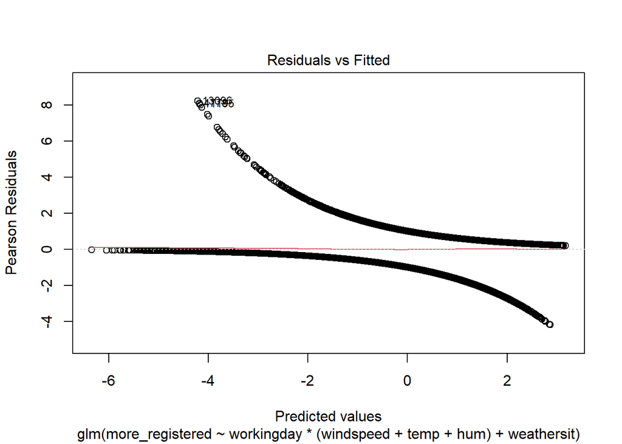

```r
plot(model6, 1)
```

This graph indeed suggests a linear relation.

Since the `car` package does not support models with interaction terms, we were unable to utilise its partial residual plots feature. Therefore, we have opted to inspect the relation between the logit values and fitted values *per* predictor:

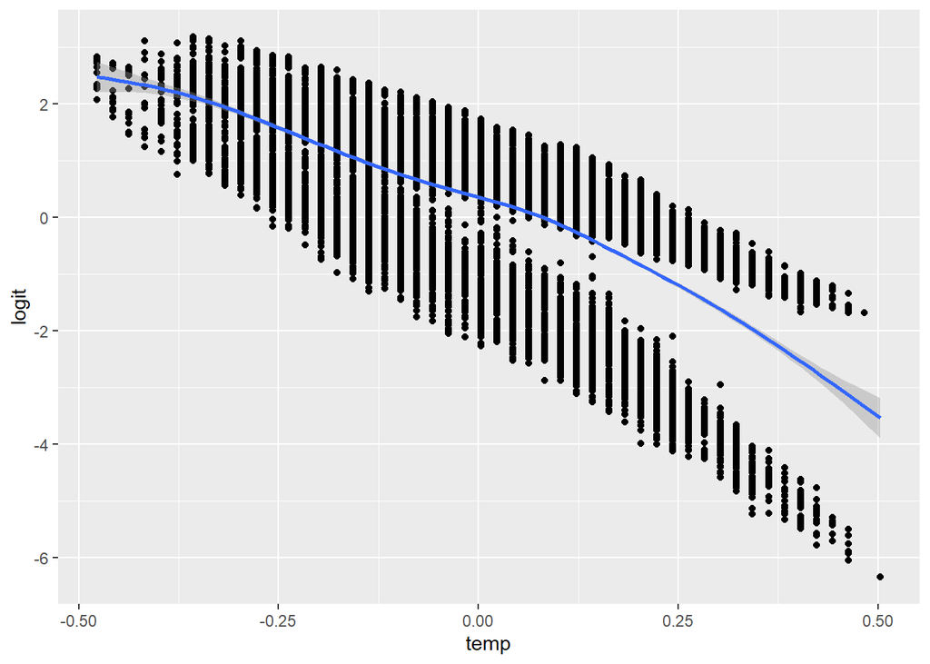

```r
data$logit <- predict(model6, type = "link")

data %>%
  ggplot(aes(temp, logit)) +
  geom_point() +
  geom_smooth()
```

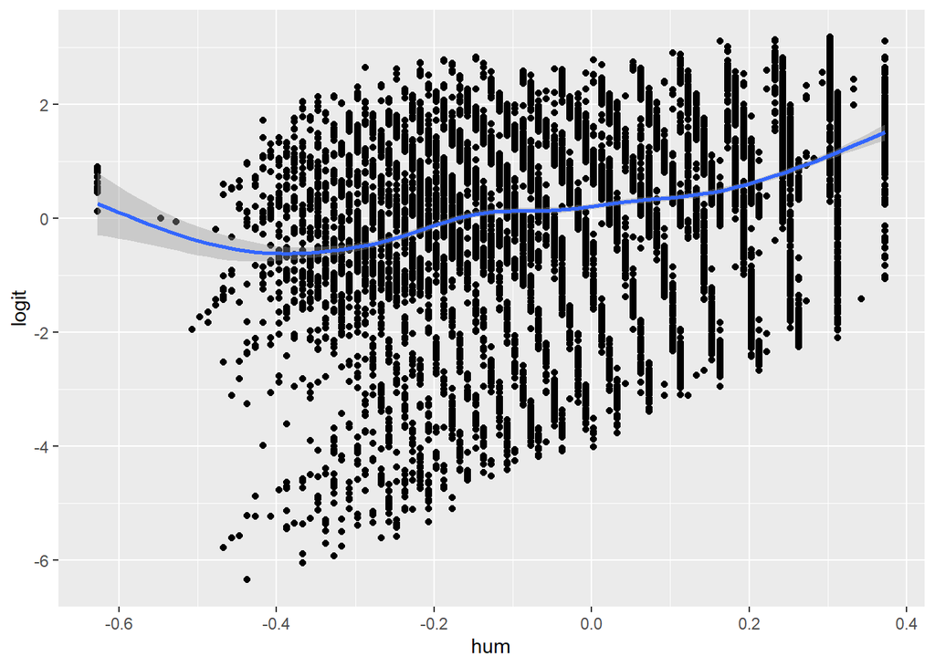

```r
data %>%
  ggplot(aes(hum, logit)) +
  geom_point() +
  geom_smooth()
```

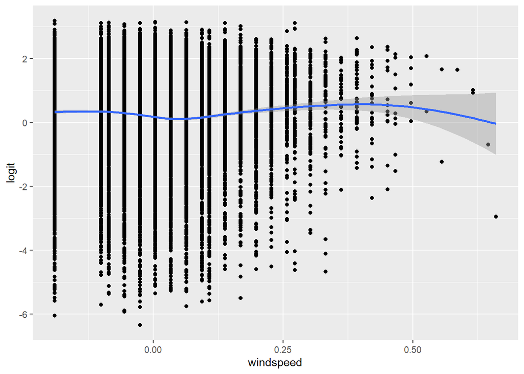

```r
data %>%
  ggplot(aes(windspeed, logit)) +
  geom_point() +
  geom_smooth()
```

## IID Binomial

The outcome of the model should be binary and follow a independent and identically distributed binomial distribution. If this assumption is violated, it might introduce a bias in our model.

For this assumption to hold, we obtain the levels of our outcome variable whilst also showing the ratio of our minority- and majority class.

```r
data %>%
  count(more_registered) %>%
  mutate(prop = round(n / sum(n), 2))
```

| more_registered | n | prop |
| --- | --- | --- |
| 0 | 7497 | 0.43 |
| 1 | 9879 | 0.57 |

Our outcome is indeed binary, moreover the outcome is balanced. Whilst the majority class occurs more often, it is nothing too egregious.

Lastly, there needs to be an absence of residual clustering within our data. To validate this absence, we calculate the ICC using the deviance residuals. With the variables provided with the data, we chose to investigate whether the `hr` class causes residual clustering:

```r
ICCbare(x = data$hr, y = resid(model6, type = "deviance"))
```

```
## [1] 0.1584112
```

## Balanced outcomes

The accuracy will be affected by an major imbalance in the outcome class. Small imbalances are handled quite well, hence these do not pose an issue in our analysis.  
As noted in our IID Binomial assumption, the outcome classes are fairly balanced. The majority class occurs 57% of the time, which we do not observe as a major imbalance.

## Sufficient sample size

Using the proportion of the minority class, obtained from previous outcome table, we can calculate the minimal amount of positive cases necessary for this assumption to hold.

```r
minimum_positive_cases <- function(k, p) {
  round((10 * k) / p)
}

minimum_positive_cases(4, 0.43)
```

```
## [1] 93
```

This assumption is easily met - there are 17376 observations.

## Influential data points

The model should not be biased due to extremely influential data points. We can measure Cook’s distance, as well as plot a residuals vs leverage plot, to check whether this assumption is violated or not.

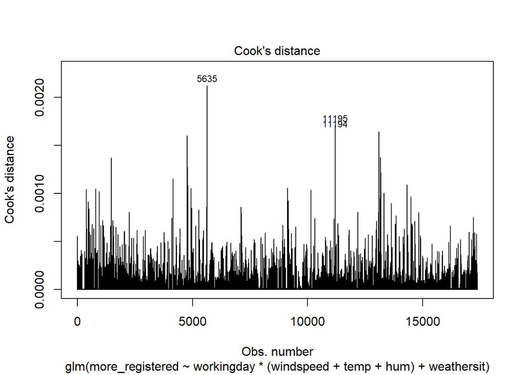

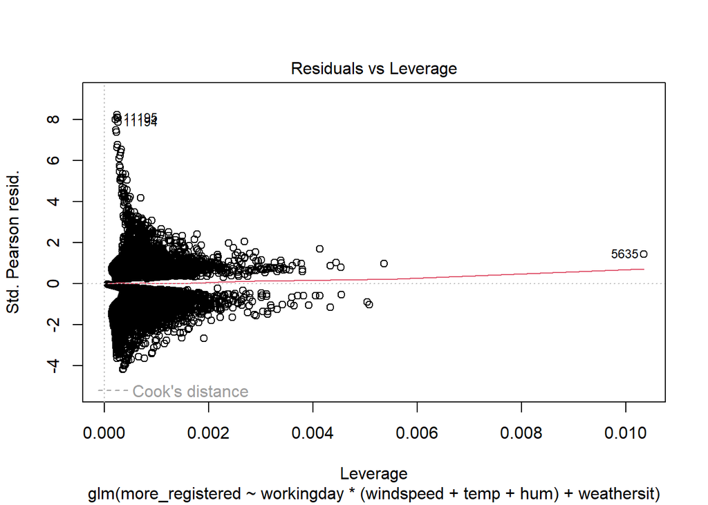

```r
plot(model6, which = c(4, 5))
```

No points seem to fall outside of the thresholds for a too large Cook’s distance, or influential leverage.

## Deviance residuals

Technically, we don’t need to check for deviance residuals as a core assumption for logistic regression. It is, however, a good way to check if the data points are fit well by the model.

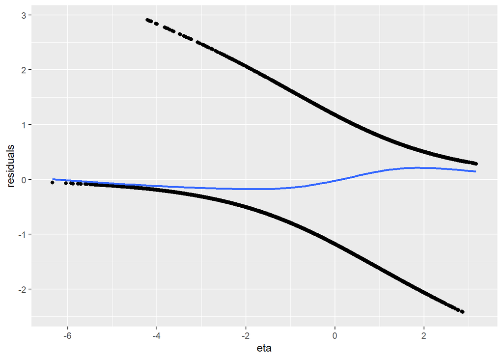

```r
dr <- resid(model6, type = "deviance")

eta <- predict(model6, type = "link")

dr_data <- data.frame(residuals = dr, eta = eta)

ggplot(dr_data, aes(x = eta, y = residuals)) +
  geom_point() +
  geom_smooth(se = FALSE)
```

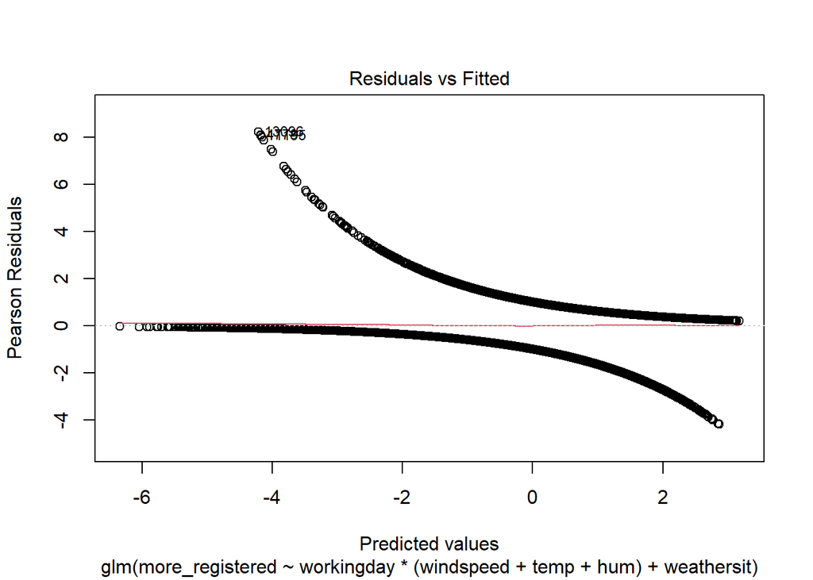

```r
plot(model6, which = 1)
```

Both regression lines should be roughly flat. Though for the first plot it seems to be a little off, nothing too violating seems to be going on. We consider these regression lines to be sufficient.

# Interpretation of final model

Based on the model comparision earlier, we chose model 6, which is represented by the following formula:
$$logit(\hat{\pi}) = \hat{\beta_0} + \hat{\beta_1}workingday +
\hat{\beta_2} windspeed + \hat{\beta_3} temp + \hat{\beta_4} hum +
\hat{\beta_5} workingday * windspeed +$$
$$+\hat{\beta_6} whethersit2 +
\hat{\beta_7}whethersit3 + \hat{\beta_8} workingday * temp +
\hat{\beta_9} workingday * hum$$

## Quality of the model

```r
summary(model6)
```

```
##
## Call:
## glm(formula = more_registered ~ workingday * (windspeed + temp +
##     hum) + weathersit, family = binomial, data = data)
##
## Coefficients:
##                       Estimate Std. Error z value Pr(>|z|)
## (Intercept)           -1.19643    0.04377 -27.334  < 2e-16 ***
## workingday1            2.12303    0.04762  44.587  < 2e-16 ***
## windspeed              1.18685    0.29264   4.056 5.00e-05 ***
## temp                  -8.02739    0.23835 -33.679  < 2e-16 ***
## hum                    2.46466    0.20457  12.048  < 2e-16 ***
## weathersit2           -0.13855    0.04376  -3.166  0.00154 **
## weathersit3            0.23005    0.07793   2.952  0.00316 **
## workingday1:windspeed -0.92209    0.34407  -2.680  0.00736 **
## workingday1:temp       3.55265    0.26861  13.226  < 2e-16 ***
## workingday1:hum       -0.91028    0.22959  -3.965 7.35e-05 ***
## ---
## Signif. codes:  0 '***' 0.001 '**' 0.01 '*' 0.05 '.' 0.1 ' ' 1
##
## (Dispersion parameter for binomial family taken to be 1)
##
##     Null deviance: 23761  on 17375  degrees of freedom
## Residual deviance: 18147  on 17366  degrees of freedom
## AIC: 18167
##
## Number of Fisher Scoring iterations: 5
```

## Classification Performance

For classification purposes use a threshold of 0.5, as in if the probability of the proportion of registered users is higher than average is 50% then the case is classified as a “success”. We decided to use the standard 0.5 threshold because we did not find any substantial reason to justifying changing it to a different value.

```r
# to create a confusion matrix we require a variable that informs us if the model classifies a given
data <- data %>%
mutate(piHat = predict(model6, type = "response"),
yHat = as.factor(ifelse(piHat <= 0.5, "0", "1"))
)

#creating the confusion matrix
cMat <- confusionMatrix(data = data$yHat, reference = data$more_registered)
cMat$table
```

```
##           Reference
## Prediction    0    1
##          0 4509 1585
##          1 2988 8294
```

```r
# extracting the Accuracy and other classification statistics for the overall model
cMat$overall
```

```
##       Accuracy          Kappa  AccuracyLower  AccuracyUpper   AccuracyNull
##   7.368209e-01   4.511785e-01   7.302053e-01   7.433572e-01   5.685428e-01
## AccuracyPValue  McnemarPValue
##   0.000000e+00   1.771321e-95
```

```r
# extracting the Accuracy and other classification statistics for Positive and Negative prediction
cMat$byClass
```

```
##          Sensitivity          Specificity       Pos Pred Value
##            0.6014406            0.8395587            0.7399081
##       Neg Pred Value            Precision               Recall
##            0.7351533            0.7399081            0.6014406
##                   F1           Prevalence       Detection Rate
##            0.6635273            0.4314572            0.2594959
## Detection Prevalence    Balanced Accuracy
##            0.3507136            0.7204996
```

### Summary of the confusion matrix

Based on the output above we find the following characteristics of our model:

[output not shown]

# References

Béland, D. 2014. *Developing Sustainable Urban Transportation*. *International Journal of Sociology and Social Policy*. Vol. 34. Emerald Group Publishing Limited. https://doi.org/10.1108/IJSSP-07-2013-0072.

Grace-Martin, Karen. 2023. “Model Building Strategies: Step up and Top Down.” *The Analysis Factor*. https://www.theanalysisfactor.com/model-building-strategies/.

Gurnsey, Frederick Norman. 2018. “MEAN-CENTERING VARIABLES AND VIF.” In *Statistics for Research in Psychology: A Modern Approach Using Estimation*. SAGE Publications.

Robinson, Cecil, and Randall E Schumacker. 2009. “Interaction Effects: Centering, Variance Inflation Factor, and Interpretation Issues.” *Multiple Linear Regression Viewpoints* 35 (1): 6–11.

Shieh, G. 2011. *Clarifying the Role of Mean Centring in Multicollinearity of Interaction Effects*. *Br J Math Stat Psychol*. Vol. 64. Emerald Group Publishing Limited. https://doi.org/10.1111/j.2044-8317.2010.02002.x.